# Exploratory Analysis

Group Members: Savannah Umali-Jepson, Sarah Peng, Lufei Wang, Ming Yan

## Introduction

### This is an exploration into organ donation data and includes data analysis on age distribution of donors, how deceased vs living donor counts have changed over time, and the relationship between the donation waitlist, organ type, and blood type. We got our data from [Table of Contents for Results Tables for the 2019 National Survey of Organ Donation Attitudes and Practices (NSODAP)](https://www.organdonor.gov/about-dot/grants/research-reports) and [Donors Recovered in the U.S. by Donor Type](https://optn.transplant.hrsa.gov/data/view-data-reports/national-data/#) .

## Distribution of Variables

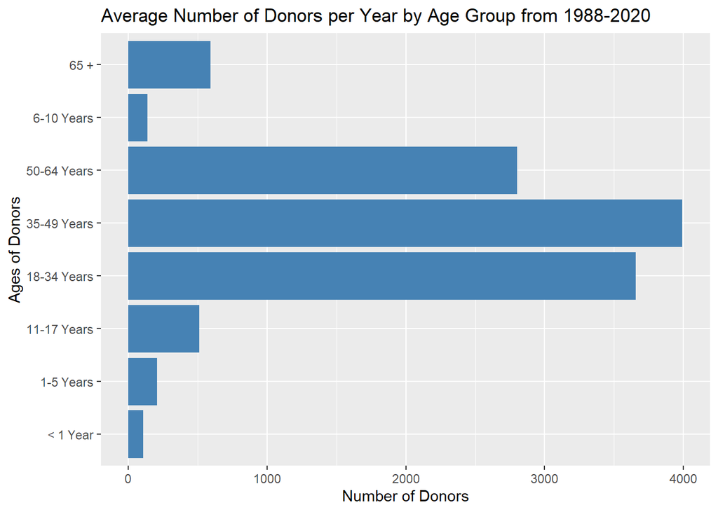

### This graph displays the distribution of the average number of donors per year by age group from 1988-2020. From this graph we can see that adults (ages 18-64), donate more than any other age group. When we think about this, it makes sense since most of the population is adults. While the elderly (ages 65+) are most likely to have more motivation to donate their organs than other age groups, since they likely have a shorter remaining life expectancy, we can see that older adults (ages 50-64) make up a larger percent of donors than elderly adults. Why would this be the case? While the elderly may be more willing, they are not likely to have as healthy organs, due to their age, making them less viable candidates to donate. Children (ages 0-17) on average donate the least. This is because children have the largest remaining life expectancy, than any other group. Most parents would not willingly allow their children to donate unless they are deceased or there are extreme circumstances. Overall this data follows a standard bell curve and has expected and understandable results.

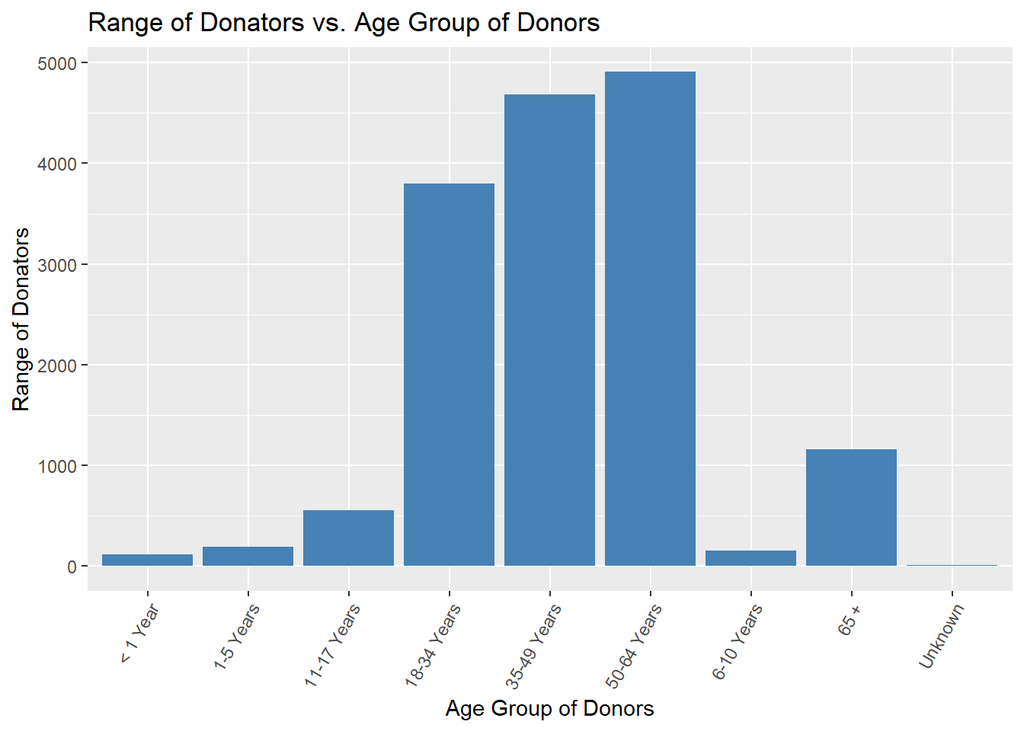

### In this graph, we see the year to year range of donors from across 9 age groups. The bar graph shows the range from 1988-2020 throughout each age group. From the graph, we see the greatest range of organ donations came from people in the age range of 50-64 years old. This means that there is a larger variability for that age group to be donors per year. For example, in 2019 there were a total of 5572 donors, but in 1988 for that age group, there were only 662 donors. That is a range of 4910 donors. Although this age group has one of the most donors per year on average, the number of donations can actually fluctuate greatly year to year. This means that there isn’t a guaranteed number of donors in this any age group (especially 50-64 year olds), so more people should donate their organs. On the other hand, age groups <1, 1-5, and 6-10 years old had a lower variability meaning the numbers of donors were more consistent from year to year. A larger range in age groups could be due to widespread illness, natural disasters, accidents or other unknown factors.

## Relationships between variables

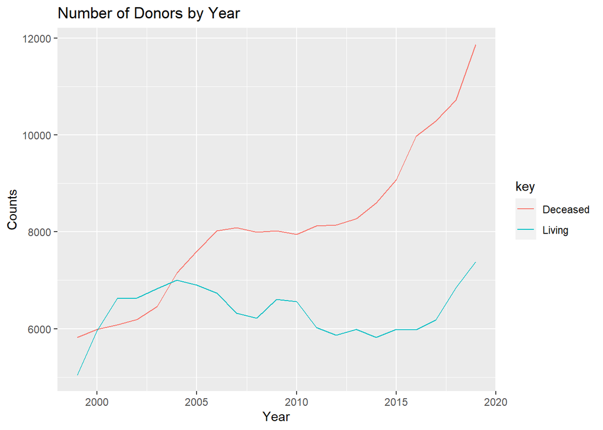

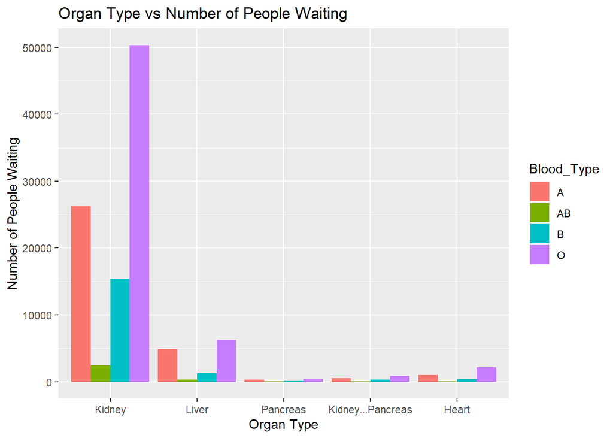

### This graph displays the relationship between the top 5 in-demand organ types and the number of people waiting for that organ by blood type. From the graph, we can see that the kidney is the most in-demand organ. The demand for kidney is about 8 times greater than the second in-demand organ,liver. This shows that although kidneys can come from living donors, kidney failure is so rampant and that there are still not enough donated organs to meet the demand. This graph also includes information on blood type.

### There are more people with blood type O waiting for donation for all organs. This is because people blood type O are compatible only with organs donated by another type O person. However, O blood type is the universal donor because all other blood types are also compatible with type O blood. Therefore, it is harder for O blood typw person to receive the right organ. Perple with AB blood type. in contrast, have the least amount of people waiting for donation because AB blood type is compatible with blood types A,B,AB or O and they are the universal recipients.